# Exploring Social Metacognition

Matt Jaquiery (matt.jaquiery@psy.ox.ac.uk)

December 2018  
[Script run 2018-12-13 11:25:00]

# Descriptives

## Introduction

This is the core analysis script for the Advisor Choice version 2 experiments. This script is designed to be agnostic as to the specific experiment run, i.e. it does not expect any particular advisor profiles.

The basic structure is:

- Load data
- Describe data
- Test primary hypothesis (pick rates are not equal)
- Test secondary hypothesis (influence is not equal)
- Exploration

Tests and explorations which depend on a specific advisor set are not included because they are out of scope for this script.

## Load data

```
## [1] "##--- Simulating Advisor Choice data ---##"
## [1] "Simulating 4500 trials from 5 participants."
## [1] "##--- Completed in 28.12s ---##"
```

```
## Loaded data from ESM_sim.R
```

```
## Generated utility variables
```

## Describe data

### Metadata

Responses (*N* = 5) were collected between 2018-12-13 11:25:03 and 2018-12-13 11:25:24.

Demographic data are not collected and therefore not analysed. Participants must be over 18 years old to use the Prolific recruitment platform.

### Task performance

#### Type 1 performance

*t*(4) = 0.70, *p* = .521, *d* = .11, BF = 0.48; *M*|initial = .71 [0.69, 0.74], *M*|final = .71 [0.69, 0.73]

#### Type 2 performance

Type 2 (metacognitive) performance is characterised using Type 2 ROC.

| decision | pCorrect |
| --- | --- |
| initial | .71 |
| final | .70 |

Participants’ ROC curves:

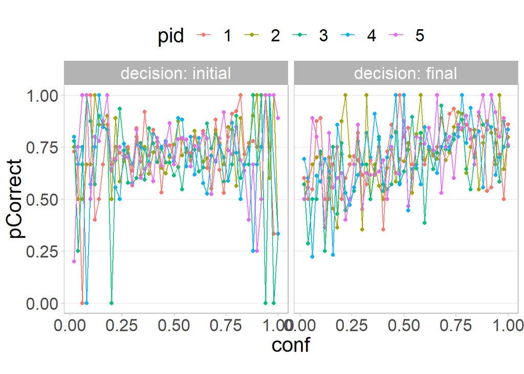

### Exclusions

We exclude participants for:

- Proportion of correct initial judgements must be (.60 < cor1/n < .90) (*N* = 0)
- Having fewer than 3 confidence categories (*N* = 0)
- Having fewer than 5% of trials in each confidence category (*N* = 0)
- There being more data collected than specified in pre-registration (*N* = 0)

*NB: **practice trials are included** in this since they are used in part for determining confidence calibration*

The number of participants analysed after exclusions (total *N* = 0) have taken place is 5.

### Advisor performance

#### Manipulation checks

The advisors need to differ appropriately. How they differ depends on the advisors being compared, but in each case we need to check the participants’ experience of the advisors matched the specifications for the advisors.

|  | mean | sd | ciLow | ciHigh | rangeLow | rangeHigh |
| --- | --- | --- | --- | --- | --- | --- |
| AiClow | .475 | .112 | .335 | .614 | .375 | .667 |
| AiUlow | .850 | .045 | .794 | .906 | .814 | .902 |
| AiCmed | .745 | .061 | .670 | .820 | .694 | .844 |
| AiUmed | .759 | .071 | .671 | .847 | .645 | .829 |
| AiChigh | .888 | .041 | .837 | .939 | .846 | .952 |
| AiUhigh | .509 | .023 | .480 | .537 | .488 | .535 |
| AiCright | .707 | .055 | .639 | .776 | .663 | .798 |
| AiUright | .698 | .024 | .668 | .728 | .678 | .739 |
| AiCwrong | .291 | .038 | .243 | .338 | .243 | .333 |
| AiUwrong | .291 | .074 | .199 | .383 | .200 | .393 |
| AiCall | .707 | .055 | .639 | .776 | .663 | .798 |
| AiUall | .698 | .024 | .668 | .728 | .678 | .739 |
| HighAccCorrect | .793 | .025 | .762 | .825 | .750 | .817 |
| LowAccCorrect | .563 | .084 | .458 | .668 | .467 | .700 |
| HighAgrAgrees | .763 | .071 | .675 | .852 | .667 | .867 |
| LowAgrAgrees | .537 | .113 | .397 | .677 | .433 | .717 |

*t*(4) = -6.29, *p* = .003, *d* = 4.38, BF = 15.87; *M*|AiClow = .47 [0.34, 0.61], *M*|AiUlow = .85 [0.79, 0.91]

*t*(4) = -0.25, *p* = .817, *d* = .21, BF = 0.41; *M*|AiCmed = .75 [0.67, 0.82], *M*|AiUmed = .76 [0.67, 0.85]

```
## t is large; approximation invoked.
```

*t*(4) = 16.61, *p* < .001, *d* = 11.47, BF = 249.80; *M*|AiChigh = .89 [0.84, 0.94], *M*|AiUhigh = .51 [0.48, 0.54]

*t*(4) = 0.29, *p* = .786, *d* = .22, BF = 0.41; *M*|AiCright = .71 [0.64, 0.78], *M*|AiUright = .70 [0.67, 0.73]

*t*(4) = -0.01, *p* = .992, *d* = .01, BF = 0.40; *M*|AiCwrong = .29 [0.24, 0.34], *M*|AiUwrong = .29 [0.20, 0.38]

*t*(4) = 0.29, *p* = .786, *d* = .22, BF = 0.41; *M*|AiCall = .71 [0.64, 0.78], *M*|AiUall = .70 [0.67, 0.73]

*t*(4) = 5.66, *p* = .005, *d* = 3.69, BF = 12.00; *M*|HighAccCorrect = .79 [0.76, 0.82], *M*|LowAccCorrect = .56 [0.46, 0.67]

*t*(4) = 2.87, *p* = .045, *d* = 2.41, BF = 2.37; *M*|HighAgrAgrees = .76 [0.68, 0.85], *M*|LowAgrAgrees = .54 [0.40, 0.68]

#### Initial decision comparability

The participants’ initial decisions should be equivalent (BF < .333) between advisors. Comparing initial decision by advice profile we can see whether this was the case:

BF = 0.55; *M*|AiC = .73 [0.67, 0.79], *M*|AiU = .69 [0.62, 0.77]

BF = 0.41; *M*|HighAcc = .71 [0.68, 0.74], *M*|LowAcc = .72 [0.67, 0.76]

BF = 0.52; *M*|HighAgr = .72 [0.69, 0.75], *M*|LowAgr = .70 [0.62, 0.78]

# Pick rate differences

The primary outcome is the relative frequencies of advisor picking on trials where there is a choice of advisor. There are two kinds of choice of advisor. *Choice* trials show participants two advisors and wait until the participant selects one. *Change* trials provide a default advisor and allow the participant to hear advice from the other advisor instead by pressing a key within a selection window (ms). These choices are distinct from one another, and are thus analysed separately.

## Choice trials

Analysis for choice trials is conducted by comparing the proportion of choices for a reference advisor to the null hypothesis of .50 using a one-sample t-test.

*t*(4) = -1.23, *p* = .286, *d* = .55, BF = 0.68; *M*|AiC = .39 [0.15, 0.63], $\mu$ = 0.5

*t*(4) = -0.84, *p* = .451, *d* = .37, BF = 0.52; *M*|HighAcc = .46 [0.34, 0.59], $\mu$ = 0.5

*t*(4) = 1.87, *p* = .134, *d* = .84, BF = 1.11; *M*|HighAgr = .64 [0.43, 0.86], $\mu$ = 0.5

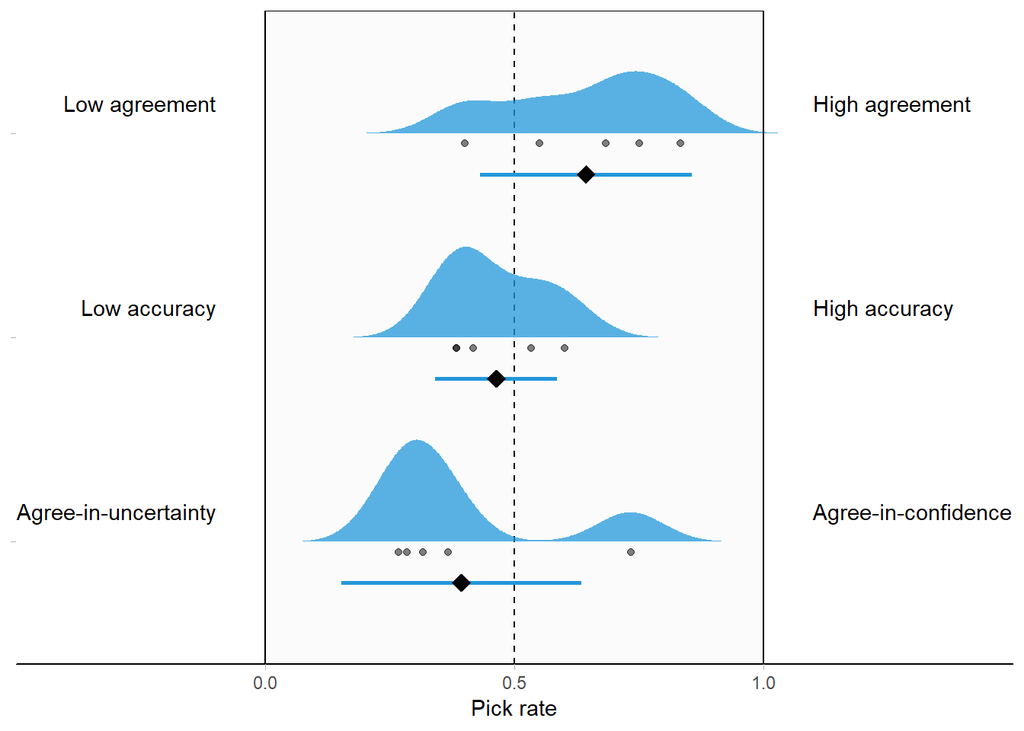

## Change trials

Change trials are analysed by looking at the proportion of changed trials where the selected advisor is the reference advisor.

*t*(4) = -0.97, *p* = .386, *d* = .44, BF = 0.57; AiC = .39 [0.06, 0.71], $\mu$ = 0.5

*t*(4) = -0.83, *p* = .454, *d* = .37, BF = 0.52; HighAcc = .48 [0.40, 0.56], $\mu$ = 0.5

*t*(4) = 3.38, *p* = .028, *d* = 1.51, BF = 3.38; HighAgr = .71 [0.54, 0.87], $\mu$ = 0.5

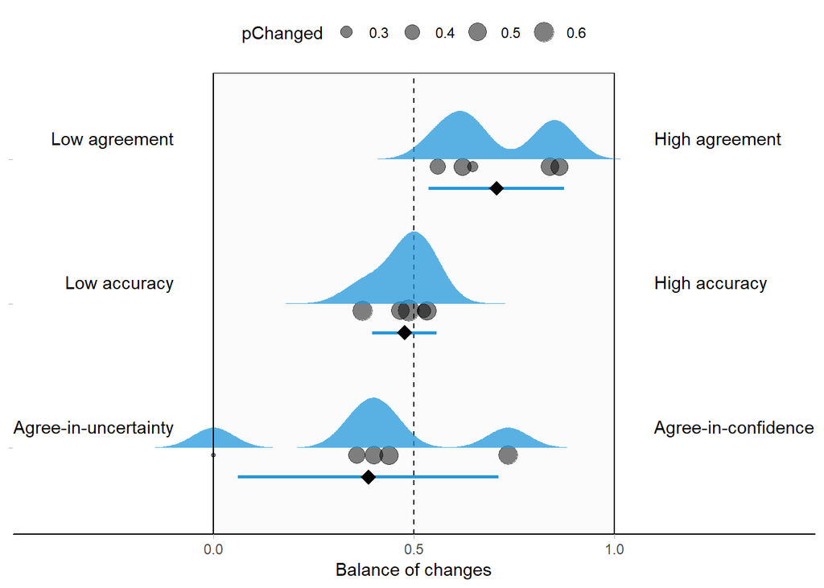

For completeness we also check the proportion of trials on which the reference advisor is the default advisor is equivalent to .5.

BF = 0.46; AiC = .45 [0.22, 0.68], $\mu$ = 0.5

BF = 0.55; HighAcc = .47 [0.38, 0.56], $\mu$ = 0.5

BF = 2.38; HighAgr = .69 [0.51, 0.87], $\mu$ = 0.5

# Influence differences

Influence, defined as the extent to which a participant adjusts their answer in the direction of an advisor’s advice, can be compared between advisors. Note that the experimental design is not optimised for measuring this outcome because influence may vary systematically with choices, and the trials without choices constitute a learning phase wherein preferences cannot be expected to have crystalised.

Influence scores are compared for trials on which a choice is not presented. For the Agree-in-Confidence/Uncertainty advisors an analysis is limited to trials where the initial decision was correct and given with medium confidence to avoid confounds of confidence * agreement. For forced trials analysis is a simple ANOVA of agreement * advice profile:

```
## [1] "Incomplete data for  Agree-in-confidence vs Agree-in-uncertainty - skipping."
## [1] "ANOVA results for High accuracy vs Low accuracy"
##                     Effect DFn DFd     F    p p<.05   ges
## 2               adviceType   1   4 38.28 .003     * .8421
## 3            advisorAgrees   1   4  5.34 .082       .0784
## 4 adviceType:advisorAgrees   1   4  3.07 .155       .0136
## [1] "ANOVA results for High agreement vs Low agreement"
##                     Effect DFn DFd      F    p p<.05   ges
## 2               adviceType   1   4 343.96 .000     * .8035
## 3            advisorAgrees   1   4   3.66 .128       .0154
## 4 adviceType:advisorAgrees   1   4  10.30 .033     * .0405
```

For dual trials the confidence shift is modelled using a linear model in which the initial confidence and the agreement of each advisor (and their interaction) are used as predictors:

```
## [1] "LM results for Agree-in-confidence vs Agree-in-uncertainty"
##
## Call:
## lm(formula = f, data = df)
##
## Residuals:
##     Min      1Q  Median      3Q     Max
## -24.495  -5.739  -0.321   6.258  33.366
##
## Coefficients:
##                                Estimate Std. Error t value Pr(>|t|)
## (Intercept)                   -11.57446    2.06750  -5.598 4.97e-08 ***
## pid                            -0.05065    0.36029  -0.141    0.888
## initialConfidence              -0.04279    0.05441  -0.786    0.432
## AiC_agreesTRUE                 22.36049    1.70402  13.122  < 2e-16 ***
## AiU_agreesTRUE                 -1.22793    1.74590  -0.703    0.482
## AiC_agreesTRUE:AiU_agreesTRUE   1.88609    2.15702   0.874    0.383
## ---
## Signif. codes:  0 '***' 0.001 '**' 0.01 '*' 0.05 '.' 0.1 ' ' 1
##
## Residual standard error: 8.721 on 294 degrees of freedom
## Multiple R-squared:  0.6254, Adjusted R-squared:  0.619
## F-statistic: 98.16 on 5 and 294 DF,  p-value: < 2.2e-16
##
## [1] "LM results for High accuracy vs Low accuracy"
##
## Call:
## lm(formula = f, data = df)
##
## Residuals:
##      Min       1Q   Median       3Q      Max
## -25.5973  -5.2588  -0.0095   5.7969  25.0544
##
## Coefficients:
##                                       Estimate Std. Error t value Pr(>|t|)
## (Intercept)                          -18.13912    1.83615  -9.879   <2e-16
## pid                                    0.54638    0.35862   1.524    0.129
## initialConfidence                      0.03150    0.05145   0.612    0.541
## HighAcc_agreesTRUE                    27.60194    1.44852  19.055   <2e-16
## LowAcc_agreesTRUE                      0.26737    1.49277   0.179    0.858
```

[output cut: 30 more lines]

```
## LowAgr_agreesTRUE                     -7.06964    2.33828  -3.023  0.00272
## HighAgr_agreesTRUE:LowAgr_agreesTRUE  -0.63815    2.66866  -0.239  0.81117
##
## (Intercept)                          ***
## pid
## initialConfidence                    *
## HighAgr_agreesTRUE                   ***
## LowAgr_agreesTRUE                    **
## HighAgr_agreesTRUE:LowAgr_agreesTRUE
## ---
## Signif. codes:  0 '***' 0.001 '**' 0.01 '*' 0.05 '.' 0.1 ' ' 1
##
## Residual standard error: 9.748 on 294 degrees of freedom
## Multiple R-squared:  0.6577, Adjusted R-squared:  0.6519
## F-statistic:   113 on 5 and 294 DF,  p-value: < 2.2e-16
```

# Pick rate x Influence

# Modelling

## Trust modelling

Models fit to the data build up by parameters to the full model:

$$C_{final} = C_{initial} + I_a * sign(A)$$
Where $A$ gives the agreement of the advice (+1 for agreement, -1 for disagreement), and the influence of an advisor $I_a$ is updated on each trial according to the rule:
$$I_{a,t} = I_{a,t-1} + \lambda C_{initial} * sign(A) - \tau$$
$\lambda$ and $\tau$ are participant-specific parameters which represent the learning rate and trust decay rates, respectively.

# Credits

## Acknowledgements

Thanks as always to Nick Yeung and the other folks at the [ACC Lab](https://www.psy.ox.ac.uk/research/attention-cognitive-control-lab).

## R Packages:

| Package | Citations |
| --- | --- |
| base | R Core Team (2018). R: A language and environment for statistical computing. R Foundation for Statistical Computing, Vienna, Austria. URL https://www.R-project.org/. |
| prettyMD | Matt Jaquiery (2018). prettyMD: Format Test Outputs with Markdown. R package version 0.1.0. |
| scoring | Merkle, E. C. & Steyvers, M. (2013). Choosing a strictly proper scoring rule. Decision Analysis, 10, 292-304. |
| Hmisc | Frank E Harrell Jr, with contributions from Charles Dupont and many others. (2018). Hmisc: Harrell Miscellaneous. R package version 4.1-1. https://CRAN.R-project.org/package=Hmisc |
| Formula | Achim Zeileis, Yves Croissant (2010). Extended Model Formulas in R: Multiple Parts and Multiple Responses. Journal of Statistical Software 34(1), 1-13. doi:10.18637/jss.v034.i01 |
| survival |  |
| lattice | Sarkar, Deepayan (2008) Lattice: Multivariate Data Visualization with R. Springer, New York. ISBN 978-0-387-75968-5 |
| knitr | Yihui Xie (2018). knitr: A General-Purpose Package for Dynamic Report Generation in R. R package version 1.20. Yihui Xie (2015) Dynamic Documents with R and knitr. 2nd edition. Chapman and Hall/CRC. I… |
| ez | Michael A. Lawrence (2016). ez: Easy Analysis and Visualization of Factorial Experiments. R package version 4.4-0. https://CRAN.R-project.org/package=ez |
| lsr | Navarro, D. J. (2015) Learning statistics with R: A tutorial for psychology students and other beginners. (Version 0.5) University of Adelaide. Adelaide, Australia |
| lme4 | Douglas Bates, Martin Maechler, Ben Bolker, Steve Walker (2015). Fitting Linear Mixed-Effects Models Using lme4. Journal of Statistical Software, 67(1), 1-48. doi:10.18637/jss.v067.i01. |
| ggridges | Claus O. Wilke (2018). ggridges: Ridgeline Plots in ‘ggplot2’. R package version 0.5.1. https://CRAN.R-project.org/package=ggridges |
| forcats | Hadley Wickham (2018). forcats: Tools for Working with Categorical Variables (Factors). R package version 0.3.0. https://CRAN.R-project.org/package=forcats |
| stringr | Hadley Wickham (2018). stringr: Simple, Consistent Wrappers for Common String Operations. R package version 1.3.1. https://CRAN.R-project.org/package=stringr |
| dplyr | Hadley Wickham, Romain François, Lionel Henry and Kirill Müller (2018). dplyr: A Grammar of Data Manipulation. R package version 0.7.6. https://CRAN.R-project.org/package=dplyr |
| purrr | Lionel Henry and Hadley Wickham (2018). purrr: Functional Programming Tools. R package version 0.2.5. https://CRAN.R-project.org/package=purrr |
| readr | Hadley Wickham, Jim Hester and Romain Francois (2017). readr: Read Rectangular Text Data. R package version 1.1.1. https://CRAN.R-project.org/package=readr |
| tidyr | Hadley Wickham and Lionel Henry (2018). tidyr: Easily Tidy Data with ‘spread()’ and ‘gather()’ Functions. R package version 0.8.1. https://CRAN.R-project.org/package=tidyr |
| tibble | Kirill Müller and Hadley Wickham (2018). tibble: Simple Data Frames. R package version 1.4.2. https://CRAN.R-project.org/package=tibble |
| ggplot2 | H. Wickham. ggplot2: Elegant Graphics for Data Analysis. Springer-Verlag New York, 2016. |
| tidyverse | Hadley Wickham (2017). tidyverse: Easily Install and Load the ‘Tidyverse’. R package version 1.2.1. https://CRAN.R-project.org/package=tidyverse |
| BayesFactor | Richard D. Morey and Jeffrey N. Rouder (2018). BayesFactor: Computation of Bayes Factors for Common Designs. R package version 0.9.12-4.2. https://CRAN.R-project.org/package=BayesFactor |
| Matrix | Douglas Bates and Martin Maechler (2018). Matrix: Sparse and Dense Matrix Classes and Methods. R package version 1.2-14. https://CRAN.R-project.org/package=Matrix |
| coda | Martyn Plummer, Nicky Best, Kate Cowles and Karen Vines (2006). CODA: Convergence Diagnosis and Output Analysis for MCMC, R News, vol 6, 7-11 |
| jsonlite | Jeroen Ooms (2014). The jsonlite Package: A Practical and Consistent Mapping Between JSON Data and R Objects. arXiv:1403.2805 [stat.CO] URL https://arxiv.org/abs/1403.2805. |

## Funding

Matt Jaquiery is funded by a studentship from the [Medical Research Council](https://mrc.ukri.org/) (reference 1943590) and the University of Oxford [Department of Experimental Psychology](https://www.psy.ox.ac.uk/) (reference 17/18_MSD_661552).